# Assignment 3

## Submit as an HTML file

Print your Emory ID below

```python
# ytu25
# 2433616
Emory_ID='2433616'
print(Emory_ID)
```

```
2433616
```

Import the numpy and matplotlib packages

```python
import numpy as np

import matplotlib.pyplot as plt

#import pandas as pd
```

(a) Compute a formula:

The formula for the volume of a cone is:

$V = \frac{1}{3} \pi r^2 h$

Where:

- $V$ is the volume of the cone
- $r$ is the radius of the base
- $h$ is the height of the cone

Calculate $V$ when:

- $r = 5$
- $h = 10$

To get full points:

- First define each of these variables
- Write the formula above
- Print out the result

```python
r=5  # radius
h=10    # height
V= (1/3)*(np.pi)*r**2*h   # Volume
print(V)
```

```
261.79938779914943
```

(b) Composite operations on arrays

- Define r = 0.1
- Define x = 1
- Define two arrays $A$ and $T$ using "np.array()", assigning the following values

$ a = \begin{pmatrix} a_1 \\ a_2 \\ a_3 \end{pmatrix} = \begin{pmatrix} 28 \\ 32 \\ 11 \end{pmatrix}, \qquad t = \begin{pmatrix} t_1 \\ t_2 \\ t_3 \end{pmatrix} = \begin{pmatrix} 4 \\ 5 \\ 6 \end{pmatrix} $

- Use element-by-element vector operations to compute a new array $M$ of length 3:

$ M = \begin{pmatrix} a_1 \cdot (1+r)^{t_1} + cos(x) \\ a_2 \cdot (1+r)^{t_2} + cos(x) \\ a_3 \cdot (1+r)^{t_3} + cos(x) \end{pmatrix} $

- Compute the sum of the values of $M$ using "M.sum()"

Note: I am using subscripts to denote the individual elements of $a$ and $t$.

- In the code just enter the values of $a$ and $t$.
- To get full points you must do all of the above tasks

```python
import numpy as np
import matplotlib.pyplot as plt
r=0.1
x=1
a_1=28
a_2=32
a_3=11
vec_a=np.array([a_1,a_2,a_3]).reshape(-1, 1)   # I want to change it into a column vector using   .reshape(-1,1)
A=vec_a
print(A)
t_1=4
t_2=5
t_3=6
vec_t=np.array([t_1,t_2,t_3]).reshape(-1,1)
T=vec_t
print(T)
# compute each entry within M
m_1=a_1*(1+r)**t_1+np.cos(x)   # row 1 of matrix M,   use ** for exponentiation within Python rather than ^
m_2=a_2*(1+r)**t_2+np.cos(x)
m_3=a_3*(1+r)**t_3+np.cos(x)
M=np.array([m_1,m_2,m_3]).reshape(-1,1)
print(M)
print(M.sum()) #lastly, sum the values using M.sum

# I discover in Python, for the cos function, need to add np. in front of it as well, not just np. for pi  (np.pi)
```

```
[[28]
 [32]
 [11]]
[[4]
 [5]
 [6]]
[[41.53510231]
 [52.07662231]
 [20.02747331]]
113.63919791760446
```

(c) Plot a normal random variable

To get full points:

- Set a seed using "np.random.seed()"
- Create the random variable with the following parameters
- mean = 233, standard deviation = 99, and size = 1314
- Create a histogram
- Label the axes

```
[212.73394171 280.41539047 181.57556721 ... 231.95133669 183.77968177
 328.4380458 ]
```

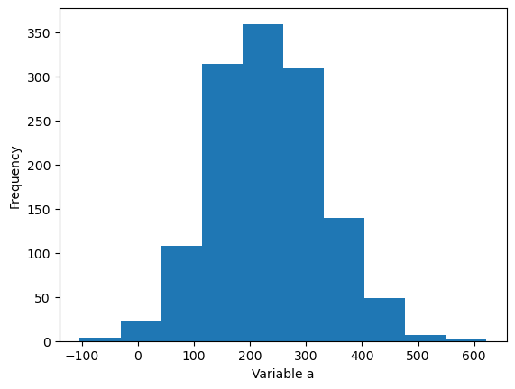

```python
np.random.seed(12345)

randomvar_x=np.random.normal(loc=233,scale=99,size=1314)
print(randomvar_x)

plt.hist(x = randomvar_x)

plt.xlabel("Variable a")
plt.ylabel("Frequency")




# np.random.normal(loc=0, scale=1, size=10)   (from lecture3, can review it)   loc means mean, meaning the geneated numbers have mean 0 here(loc=0). scale means sd
```

(d) Checking whether word is part of list

- Define a variable "QSS" with the value "Statistics"
- Define a list of fruits with the values list_QSS = ["Statistics", "CS", "Dara Science", "Math"]
- Write an expression to test whether "QSS" is contained in "list_QSS"

Hint: Use the "in" command. The final output should be True/False.

To get full points run all of the above commands

```python
QSS="Statistics"
list_QSS=["Statistics", "CS","Data Science","Math"]

QSS in list_QSS    # I expect the value to be true, since there is no additional pairs of brackets for the elements within list_QSS. Otherwise it might be false.

# Result: True
```

```
True
```

(e) Classifying a variable

- Define a new variable "film_score" and assign it "70"
- Write an if/else statement that does the following
  - print("Box-office Success") if the score is strictly above 80.
  - print("Intermediate Range") if the score is weakly less than 80 and strictly above 20.
  - print("Box-office Failure") if the score does not fit in the above categories.

To get full points you must do all of the above instructions

```python
film_score=70     #  Intermediate Range

# Additional Test cases:

# film_score=10000   # Returns:Box-office Success
# film_score=0       # Box-office Failure
# film_score=80    #   Intermediate Range
# film_score=81    #  Box-office Success
# film_score=20    #  Box-office Failure

if film_score>80:
   print("Box-office Success")

elif film_score>20:
   print("Intermediate Range")

else:
   print("Box-office Failure")
```

```
Intermediate Range
```